# Lab 8

Tianhao Jiang

I chose the high-pT samples.

```python
# import libraries
import pickle
import numpy as np
import matplotlib
import matplotlib.cm as cm
import matplotlib.pyplot as plt
import scipy
import math
import h5py
import pandas as pd
from scipy import stats
from scipy import signal
from math import floor

#this sets the size of the plot to something useful
plt.rcParams["figure.figsize"] = (20,15)
```

```python
# open the file of interest, and use pickle loading
infile = open ("Sample_pt_1000_1200/qcd_100000_pt_1000_1200.pkl",'rb')
qcd = pickle.load(infile)
infile = open ("Sample_pt_1000_1200/higgs_100000_pt_1000_1200.pkl",'rb')
higgs = pickle.load(infile)

# list all keys of the files
print('Variables in data:')
#print(qcd.keys())
print(higgs.keys())

# Number of data points in training data
n_total = len(higgs) # = 100000

# Original expected yields
n_higgs = 50
n_qcd = 2000
```

```
Variables in data:
Index(['pt', 'eta', 'phi', 'mass', 'ee2', 'ee3', 'd2', 'angularity', 't1',
       't2', 't3', 't21', 't32', 'KtDeltaR'],
      dtype='object')
```

```python
#import the data
hf = h5py.File('Sample_pt_1000_1200/data_lowLumi_pt_1000_1200.h5', 'r')
data_low_raw = np.array(hf.get('data/block0_values'))
hf.close()
hf = h5py.File('Sample_pt_1000_1200/data_highLumi_pt_1000_1200.h5', 'r')
data_high_raw = np.array(hf.get('data/block0_values'))
hf.close()
data_low = {} # Low luminosity data
data_high = {} # High luminosity data
keys = higgs.keys()
for i in range(len(keys)):
    data_low[keys[i]] = data_low_raw[:,i]
    data_high[keys[i]] = data_high_raw[:,i]
data_low = pd.DataFrame(data=data_low)
data_high = pd.DataFrame(data=data_high)
```

The expected yield of signal and background for Lab 7 were 50 and 2000, respectively.

For Lab 8, I normalized them to ovserved data by scaling them down so that their sums equal the observed yields:

```python
# Normalize to high luminosity data
n_higgs_high = n_higgs/(n_higgs+n_qcd)*len(data_high)
n_qcd_high = n_qcd/(n_higgs+n_qcd)*len(data_high)

# Normalize to low luminosity data
n_higgs_low = n_higgs/(n_higgs+n_qcd)*len(data_low)
n_qcd_low = n_qcd/(n_higgs+n_qcd)*len(data_low)
```

From Lab 7, I decided that my optimal set of cuts consisted of 4 cuts, two cuts on the mass feature and two on the d2 feature:

My optimal set of mass cuts: (left, right) = (124.98224260383364, 128.09318340257153)

My optimal set of d2 cuts: (left, right) = (0.27837101274447207, 1.0504993443653543)

After the 4 cuts, 24% of my signals was left, but only 2 out of 100000 background points were left. So I'm not sure if my choices on the cuts were correct. Also, with only two background data points left, I'm not sure if my significance calculations would be accurate.

```python
mass_cuts = (124.98224260383364, 128.09318340257153)
d2_cuts = (0.27837101274447207, 1.0504993443653543)
def make_cuts(dataset):
    return (dataset["mass"] >= mass_cuts[0]) & (dataset["mass"] <= mass_cuts[1]) \
        & (dataset["d2"] >= d2_cuts[0]) & (dataset["d2"] <= d2_cuts[1])
bkgd_cuts = make_cuts(qcd)
signal_cuts = make_cuts(higgs)
data_high_cuts = make_cuts(data_high)
data_low_cuts = make_cuts(data_low)

# function to plot histograms
def compare(ax, data, signal, bkgd, param, n_higgs, n_qcd, sigmas = 4, num_bins = 200,fontsize = 20):
    left1 = np.min([np.min(bkgd),np.min(signal)])
    left2 = np.min([np.mean(bkgd)-sigmas*np.std(bkgd), np.mean(signal)-sigmas*np.std(signal)])
    left = np.max([left1,left2])
    right1 = np.max([np.max(bkgd),np.max(signal)])
    right2 = np.max([np.mean(bkgd)+sigmas*np.std(bkgd), np.mean(signal)+sigmas*np.std(signal)])
    bins = np.linspace(np.max([left1,left2]),np.min([right1,right2]),num_bins)
    weights_signal = [n_higgs/len(higgs)]*len(signal)
    weights_bkgd = [n_qcd/len(higgs)]*len(bkgd)
    ax.hist(data, bins=bins, alpha = 0.5, color = 'g',label = 'Observed data')
    ax.hist([signal,bkgd], bins=bins, alpha = 0.5, color= ['r','b'], stacked = True, label = ['Expected signal','Expected background'],\
             ls='dashed', weights = [weights_signal,weights_bkgd])
    ax.legend(prop={'size': fontsize})
    ax.set_ylabel("Counts",fontsize=fontsize)
    ax.set_xlabel(param,fontsize=fontsize)
    ax.set_title('%s: Histograms of observed data & expected background stacked on signal' % param,fontsize=int(fontsize*1.25))
```

**1. High luminosity data**

- **Focus on each feature of your event selection.**
- **Plot observed data, overlap with expected signal and background (normalized to observed yields) without event selection.** Below I plotted the histogram of the observed high luminosity data overlapped with the stacked histogram of (normalized) expected signal and background for the mass and d2 features.

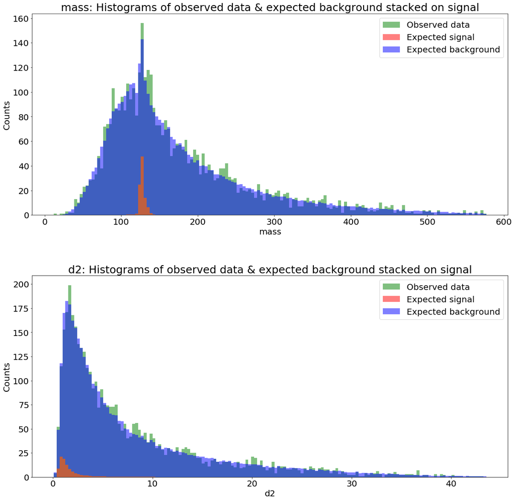

```python
plt.rcParams.update({'font.size': 20})
fig, axs = plt.subplots(2, 1, figsize=(20,20))
plt.subplots_adjust(left=None, bottom=None, right=None, top=None, wspace=None, hspace=.3)
i = 0
params = ['mass', 'd2']
for param in params:
    ax = axs[i]
    compare(ax, data_high[param], higgs[param], qcd[param], param, n_higgs_high ,n_qcd_high, fontsize = 20,num_bins = 150)
    #ax.set_yscale("log")
    i = i+1
plt.show()
```

The data and the signal+background histogram do seem to overlap.

- **Plot observed data, overlap with expected signal and background (normalized to observed yields) with optimal event selection.**

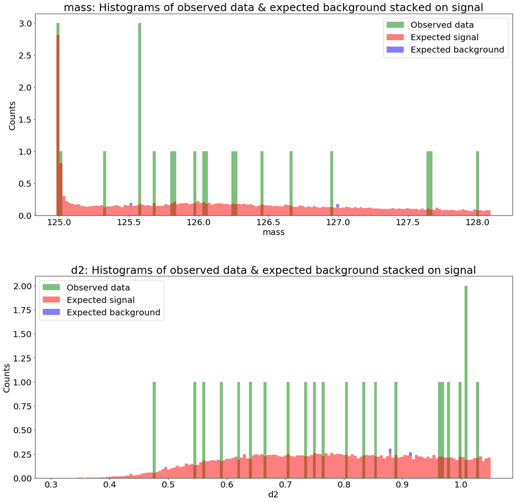

```python
plt.rcParams.update({'font.size': 20})
fig, axs = plt.subplots(2, 1, figsize=(20,20))
plt.subplots_adjust(left=None, bottom=None, right=None, top=None, wspace=None, hspace=.3)
i = 0
params = ['mass', 'd2']
for param in params:
    ax = axs[i]
    compare(ax, data_high[param][data_high_cuts], higgs[param][signal_cuts], qcd[param][bkgd_cuts], \
            param, n_higgs_high ,n_qcd_high, fontsize = 20,num_bins = 150)
    #ax.set_yscale("log")
    i = i+1
plt.show()
```

- **Evaluate observed significance and compare your results to expectation**

Scipy.stats functions cannot handle significances as high as ~60 sigmas, so I will use N_Higgs/(√N_QCD) to calculate the significances instead.

I'm not sure how exactly I should calculate the observed significance because the observed n_qcd is not given. In my calculation, I just approximated the observed n_qcd by the expected n_qcd.

```python
# Counts of higgs, qcd, high luminosity data after optimal cuts
n_cut_higgs_high = len(higgs["d2"][signal_cuts])*n_higgs_high/n_total
n_cut_qcd_high = len(qcd["d2"][bkgd_cuts])*n_qcd_high/n_total
n_cut_data_high = len(data_high["d2"][data_high_cuts])

exp_sig_high = n_cut_higgs_high/np.sqrt(n_cut_qcd_high) # expected significance for high luminosity data
obs_sig_high = (n_cut_data_high-n_cut_qcd_high)/np.sqrt(n_cut_qcd_high) # expected significance for high luminosity data
print("When no cut is applied:")
print("(expected_signal_count, expected_backgrounds_count, high_lumi_data_count) = %s" % str((n_higgs_high,n_qcd_high,len(data_high))))
print("Expected significance for high luminosity data: %.2f-sigmas" % (n_higgs_high/np.sqrt(n_qcd_high)))
print("Observed significance for high luminosity data: %.2f-sigmas" % (n_higgs_high/np.sqrt(n_qcd_high)))

print("\nWith optimal cuts applied:")
print("(expected_signal_count, expected_backgrounds_count, high_lumi_data_count) = %s" % str((n_cut_higgs_high,n_cut_qcd_high,n_cut_data_high)))
print("Expected significance for high luminosity data: %.2f-sigmas" % exp_sig_high)
print("Observed significance for high luminosity data: %.2f-sigmas" % obs_sig_high)
```

```
When no cut is applied:
(expected_signal_count, expected_backgrounds_count, high_lumi_data_count) = (99.17073170731707, 3966.8292682926826, 4066)
Expected significance for high luminosity data: 1.57-sigmas
Observed significance for high luminosity data: 1.57-sigmas

With optimal cuts applied:
(expected_signal_count, expected_backgrounds_count, high_lumi_data_count) = (24.368232195121955, 0.07933658536585365, 22)
Expected significance for high luminosity data: 86.51-sigmas
Observed significance for high luminosity data: 77.82-sigmas
```

When no cut is applied, the significance is lower than 5-sigmas.

When the optimal cuts are applied, both the expected and the observed significance values are very high. The observed significance is a bit lower than the expected.

**2. Low luminosity data**

- **Focus on each feature of your event selection.**
- **Plot observed data, overlap with expected signal and background (normalized to observed yields) without event selection.**

Again, I plotted the histogram of the observed low luminosity data overlapped with the stacked histogram of (normalized) expected signal and background for the mass and d2 features.

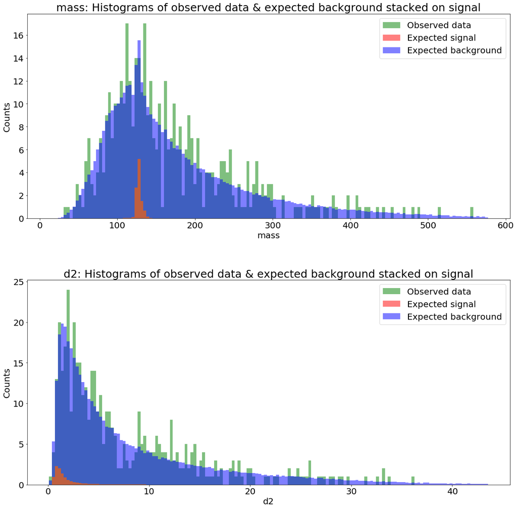

```python
plt.rcParams.update({'font.size': 20})
fig, axs = plt.subplots(2, 1, figsize=(20,20))
plt.subplots_adjust(left=None, bottom=None, right=None, top=None, wspace=None, hspace=.3)
i = 0
params = ['mass', 'd2']
for param in params:
    ax = axs[i]
    compare(ax, data_low[param], higgs[param], qcd[param], param, n_higgs_low ,n_qcd_low, fontsize = 20,num_bins = 150)
    #ax.set_yscale("log")
    i = i+1
plt.show()
```

The data and the signal+background histogram do seem to overlap.

- **Plot observed data, overlap with expected signal and background (normalized to observed yields) with optimal event selection.**

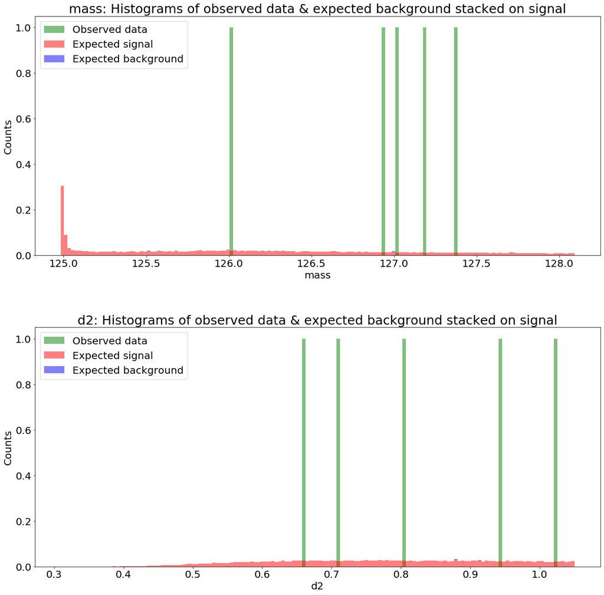

```python
plt.rcParams.update({'font.size': 20})
fig, axs = plt.subplots(2, 1, figsize=(20,20))
plt.subplots_adjust(left=None, bottom=None, right=None, top=None, wspace=None, hspace=.3)
i = 0
params = ['mass', 'd2']
for param in params:
    ax = axs[i]
    compare(ax, data_low[param][data_low_cuts], higgs[param][signal_cuts], qcd[param][bkgd_cuts], \
            param, n_higgs_low ,n_qcd_low, fontsize = 20,num_bins = 150)
    #ax.set_yscale("log")
    i = i+1
plt.show()
```

- **Evaluate observed significance and compare your results to expectation**

```python
# Counts of higgs, qcd, low luminosity data after optimal cuts
n_cut_higgs_low = len(higgs["d2"][signal_cuts])*n_higgs_low/n_total
n_cut_qcd_low = len(qcd["d2"][bkgd_cuts])*n_qcd_low/n_total
n_cut_data_low = len(data_low["d2"][data_low_cuts])

exp_sig_low = n_cut_higgs_low/np.sqrt(n_cut_qcd_low) # expected significance for low luminosity data
obs_sig_low = (n_cut_data_low-n_cut_qcd_low)/np.sqrt(n_cut_qcd_low) # expected significance for low luminosity data
print("When no cut is applied:")
print("(expected_signal_count, expected_backgrounds_count, low_lumi_data_count) = %s" % str((n_higgs_low,n_qcd_low,len(data_low))))
print("Expected significance for low luminosity data: %.2f-sigmas" % (n_higgs_low/np.sqrt(n_qcd_low)))
print("Observed significance for low luminosity data: %.2f-sigmas" % (n_higgs_low/np.sqrt(n_qcd_low)))

print("\nWith optimal cuts applied:")
print("(expected_signal_count, expected_backgrounds_count, low_lumi_data_count) = %s" % str((n_cut_higgs_low,n_cut_qcd_low,n_cut_data_low)))
print("Expected significance for low luminosity data: %.2f-sigmas" % exp_sig_low)
print("Observed significance for low luminosity data: %.2f-sigmas" % obs_sig_low)
```

```
When no cut is applied:
(expected_signal_count, expected_backgrounds_count, low_lumi_data_count) = (10.78048780487805, 431.2195121951219, 442)
Expected significance for low luminosity data: 0.52-sigmas
Observed significance for low luminosity data: 0.52-sigmas

With optimal cuts applied:
(expected_signal_count, expected_backgrounds_count, low_lumi_data_count) = (2.6489814634146343, 0.008624390243902439, 5)
Expected significance for low luminosity data: 28.52-sigmas
Observed significance for low luminosity data: 53.75-sigmas
```

When no cut is applied, the significance is lower than 5-sigmas.

When my optimal cuts are applied, the expected and the observed significance values are still very high. The observed significance is now bigger than the expected.

**3. 95% Confidence Level of signal yields**

- **In the low luminosity data, the observed significance is less than 5-σ . We will calculate the 95% confidence level upper limit of signal yield.**

I'm not sure the question is talking about the significance before or after event selections.

With my optimal cuts applied, the observed significance value I got was much larger than 5-sigmas. I'm not sure if anything went wrong.

- **Evaluate the expected 95% confidence level upper limit**
- **Evaluate the observed 95% confidence level upper limit**
- **Compare expectation to observation. Comment on your finding.**

Assume that my expected/observed number of yields is x and my corresponding 95% confidence level upper limit is y, then we have

95% = \<probability that background is within (x-y, x)> / \<probability that background is within (0, x)>

If we assume the real signal is from a uniform distribution, then the expected/observed 95% confidence level upper limit should be the observed/expected yields minus the (1-95%*(integral of background distribution from 0 to the observed/expected yields)) percentile of the background distribution.

I will calculate the confidence level upper limit assuming the backgrounds follow Poisson distributions.

```python
def find_upper_limit(n_data,n_bkgd):
    return n_data - stats.poisson.ppf((1-0.95)*stats.poisson.cdf(n_data,n_bkgd),n_bkgd)
upper_limit = find_upper_limit(len(data_low), n_qcd_low)
upper_limit_cut_expected = find_upper_limit(n_cut_higgs_low + n_cut_qcd_low, n_cut_qcd_low)
upper_limit_cut_observed = find_upper_limit(n_cut_data_low,n_cut_qcd_low)
print("95 percent confidence level upper limit without event selection: %f" % upper_limit)
print("Expected 95 percent confidence level upper limit with my optimal cuts: %f" % upper_limit_cut_expected)
print("Observed 95 percent confidence level upper limit with my optimal cuts: %f" % upper_limit_cut_observed)
```

```
95 percent confidence level upper limit without event selection: 48.000000
Expected 95 percent confidence level upper limit with my optimal cuts: 2.657606
Observed 95 percent confidence level upper limit with my optimal cuts: 5.000000
```

With my optimal cuts applied, my expected and observed upper limits are almost exactly the same as the expected and observed yields. This is because my expected value of background counts (which is 0.0086) is too small to influence my signal observations.